# R ile analize başlarken<a href="#fn1" class="footnote-ref" id="fnref1"><sup>1</sup></a>

### Derleyen <a href="https://sbalci.github.io/">Serdar Balcı, MD, Pathologist</a>

### <a href="https://www.serdarbalci.com">serdarbalci.com</a>

### 2019-09-25

[figure not shown]

# R nerede kullanılır

- Veri düzenleme
- İstatistik analiz
- Web sayfası hazırlama (Statik/Dinamik)
https://sbalci.github.io/
https://kevinrue.shinyapps.io/isee-shiny-contest/
- Sunum hazırlama (bu sunum)
- Programlama
https://serdarbalci.netlify.com/pathtweets/
- Otomatik, periodik ve tekrarlanabilir rapor hazırlama
https://sbalci.github.io/AutoJournalWatch/GallbladderRecent.html
- pdf, html, ppt oluşturma
- tez yazma
- kitap yazma
- CV oluşturma
https://rpubs.com/sbalci/CV
- poster hazırlama
- rapor şablonu oluşturma
- Robot uygulamaları (Arudino kodu)
- ...

# R generation

R yıllar içinde çok fazla değişim gösterdi

https://rss.onlinelibrary.wiley.com/doi/10.1111/j.1740-9713.2018.01169.x

[figure not shown]

# R yükleme

http://www.youtube.com/watch?v=XcBLEVknqvY

[figure not shown]

## R-project

https://cran.r-project.org/

## RStudio

[figure not shown]

### RStudio

[https://www.rstudio.com/](https://www.rstudio.com/)

[https://www.rstudio.com/products/rstudio/download/](https://www.rstudio.com/products/rstudio/download/)

[https://moderndive.com/2-getting-started.html](https://moderndive.com/2-getting-started.html)

### RStudio

[figure not shown]

### RStudio eklentileri

- Discover and install useful RStudio addins

https://cran.r-project.org/web/packages/addinslist/README.html

https://rstudio.github.io/rstudioaddins/

```
devtools::install_github("rstudio/addinexamples", type = "source")
```

## MacOS için

### X11

https://www.xquartz.org/

### Java OS

https://support.apple.com/kb/dl1572

# R zor şeyler için kolay, kolay şeyler için zor

- [R makes easy things hard, and hard things easy](http://r4stats.com/articles/why-r-is-hard-to-learn/)

- Aynı şeyi çok fazla şekilde yapmak mümkün

R Syntax Comparison::CHEAT SHEET

https://www.amelia.mn/Syntax-cheatsheet.pdf

> [#RStats](https://twitter.com/hashtag/RStats?src=hash&ref_src=twsrc%5Etfw) — There are always several ways to do the same thing... nice example on with the identity matrix by [@TeaStats](https://twitter.com/TeaStats?ref_src=twsrc%5Etfw) https://t.co/O3GXdPiM32

> — Colin Fay 🤘 (@_ColinFay) [April 1, 2019](https://twitter.com/_ColinFay/status/1112746633467518977?ref_src=twsrc%5Etfw)

# R paketleri

## Neden paketler var

[figure not shown]

> I love the [#rstats](https://twitter.com/hashtag/rstats?src=hash&ref_src=twsrc%5Etfw) community.  
> Someone is like, "oh hey peeps, I saw a big need for this mundane but difficult task that I infrequently do, so I created a package that will literally scrape the last bits of peanut butter out of the jar for you. It's called pbplyr."  
> What a tribe.

> — Frank Elavsky ᴰᵃᵗᵃ ᵂᶦᶻᵃʳᵈ (@Frankly_Data) [July 3, 2018](https://twitter.com/Frankly_Data/status/1014189095294291968?ref_src=twsrc%5Etfw)

[figure not shown]

## Paketleri nereden bulabiliriz

- Available CRAN Packages By Name
https://cran.r-project.org/web/packages/available_packages_by_name.html

- CRAN Task Views
https://cran.r-project.org/web/views/

- Bioconductor
https://www.bioconductor.org

- RecommendR
http://recommendr.info/

- pkgsearch
CRAN package search
https://github.com/metacran/pkgsearch

- CRANsearcher
https://github.com/RhoInc/CRANsearcher

- Awesome R
https://awesome-r.com/

## Kendi paket evrenini oluştur

- pkgverse: Build a Meta-Package Universe
https://cran.r-project.org/web/packages/pkgverse/index.html

## R paket yükleme

```
install.packages("tidyverse", dependencies = TRUE)
install.packages("jmv", dependencies = TRUE)
install.packages("questionr", dependencies = TRUE)
install.packages("Rcmdr", dependencies = TRUE)
install.packages("summarytools")
```

## Paket çağırma

```r
# require(tidyverse) require(jmv) require(questionr) library(summarytools)
# library(gganimate)
```

# R için yardım bulma

- Vignette

[figure not shown]

- RDocumentation
https://www.rdocumentation.org

- R Package Documentation
https://rdrr.io/

- GitHub

- Stackoverflow

https://stackoverflow.com/

- Google uygun anahtar kelime

> How I use [#rstats](https://twitter.com/hashtag/rstats?src=hash&ref_src=twsrc%5Etfw)  
> h/t [@ThePracticalDev](https://twitter.com/ThePracticalDev?ref_src=twsrc%5Etfw) [pic.twitter.com/erRnTG0Ujr](https://t.co/erRnTG0Ujr)

> — Emily Bovee (@ebovee09) [August 10, 2018](https://twitter.com/ebovee09/status/1028037594947485696?ref_src=twsrc%5Etfw)

[figure not shown]

- Google'da ararken `[R]` yazmak da işe yarayabiliyor.

- searcher package 📦

[figure not shown]

- Awesome Cheatsheet
https://github.com/detailyang/awesome-cheatsheet

http://cran.r-project.org/doc/contrib/Baggott-refcard-v2.pdf

https://www.rstudio.com/resources/cheatsheets/

- Awesome R

https://github.com/qinwf/awesome-R#readme

https://awesome-r.com/

- Twitter

https://twitter.com/hashtag/rstats?src=hash

- Use Reproducible Examples When Asking

> Got a question to ask on [@SlackHQ](https://twitter.com/SlackHQ?ref_src=twsrc%5Etfw) or post on [@github](https://twitter.com/github?ref_src=twsrc%5Etfw)? No time to read the long post on how to use reprex? Here is a 20-second gif for you to format your R codes nicely and for others to reproduce your problem. (An example from a talk given by [@JennyBryan](https://twitter.com/JennyBryan?ref_src=twsrc%5Etfw)) [#rstat](https://twitter.com/hashtag/rstat?src=hash&ref_src=twsrc%5Etfw) [pic.twitter.com/gpuGXpFIsX](https://t.co/gpuGXpFIsX)

> — ZhiYang (@zhiiiyang) [October 18, 2018](https://twitter.com/zhiiiyang/status/1053006003711569920?ref_src=twsrc%5Etfw)

- Keeping up to date with R news
https://masalmon.eu/2019/01/25/uptodate/

# Rstudio ile proje oluşturma

https://support.rstudio.com/hc/en-us/articles/200526207-Using-Projects

[figure not shown]

# RStudio ile veri yükleme

https://support.rstudio.com/hc/en-us/articles/218611977-Importing-Data-with-RStudio

[figure not shown]

## Excel

## SPSS

## CSV

# Veriyi görüntüleme

> Spreadsheet users using [#rstats](https://twitter.com/hashtag/rstats?src=hash&ref_src=twsrc%5Etfw): where's the data?[#rstats](https://twitter.com/hashtag/rstats?src=hash&ref_src=twsrc%5Etfw) users using spreadsheets: where's the code?

> — Leonard Kiefer (@lenkiefer) [July 7, 2018](https://twitter.com/lenkiefer/status/1015587475580956672?ref_src=twsrc%5Etfw)

# Veriyi görüntüleme

```
View(data)
```

```
data
```

```
head
```

```
tail
```

```
glimpse
```

```
str
```

```
skimr::skim()
```

# Veriyi değiştirme

## Veriyi kod ile değiştirelim

## Veriyi eklentilerle değiştirme

[figure not shown]

## RStudio aracılığıyla recode

*questionr* paketi kullanılacak

[figure not shown]

https://juba.github.io/questionr/articles/recoding_addins.html

[figure not shown]

# Basit tanımlayıcı istatistikler

```
summary()
```

```
mean
```

```
median
```

```
min
```

```
max
```

```
sd
```

```
table()
```

```r
library(readr)
irisdata <- read_csv("data/iris.csv")

jmv::descriptives(data = irisdata, vars = "Sepal.Length", splitBy = "Species",
    freq = TRUE, hist = TRUE, dens = TRUE, bar = TRUE, box = TRUE, violin = TRUE,
    dot = TRUE, mode = TRUE, sum = TRUE, sd = TRUE, variance = TRUE, range = TRUE,
    se = TRUE, skew = TRUE, kurt = TRUE, quart = TRUE, pcEqGr = TRUE)
```

```
 DESCRIPTIVES

 Descriptives
 ─────────────────────────────────────────────────────
                          Species       Sepal.Length
 ─────────────────────────────────────────────────────
   N                      setosa                  50
                          versicolor              50
                          virginica               50
   Missing                setosa                   0
                          versicolor               0
                          virginica                0
   Mean                   setosa                5.01
                          versicolor            5.94
                          virginica             6.59
   Std. error mean        setosa              0.0498
                          versicolor          0.0730
                          virginica           0.0899
   Median                 setosa                5.00
                          versicolor            5.90
                          virginica             6.50
   Mode                   setosa                5.00
                          versicolor            5.50
                          virginica             6.30
   Sum                    setosa                 250
                          versicolor             297
                          virginica              329
   Standard deviation     setosa               0.352
                          versicolor           0.516
                          virginica            0.636
   Variance               setosa               0.124
                          versicolor           0.266
                          virginica            0.404
   Range                  setosa                1.50
                          versicolor            2.10
                          virginica             3.00
   Minimum                setosa                4.30
                          versicolor            4.90
                          virginica             4.90
   Maximum                setosa                5.80
                          versicolor            7.00
                          virginica             7.90
   Skewness               setosa               0.120
                          versicolor           0.105
                          virginica            0.118
   Std. error skewness    setosa               0.337
                          versicolor           0.337
                          virginica            0.337
   Kurtosis               setosa              -0.253
                          versicolor          -0.533
                          virginica           0.0329
   Std. error kurtosis    setosa               0.662
                          versicolor           0.662
                          virginica            0.662
   25th percentile        setosa                4.80
                          versicolor            5.60
                          virginica             6.23
   50th percentile        setosa                5.00
                          versicolor            5.90
                          virginica             6.50
   75th percentile        setosa                5.20
                          versicolor            6.30
                          virginica             6.90
 ─────────────────────────────────────────────────────
```

[figure not shown]

[figure not shown]

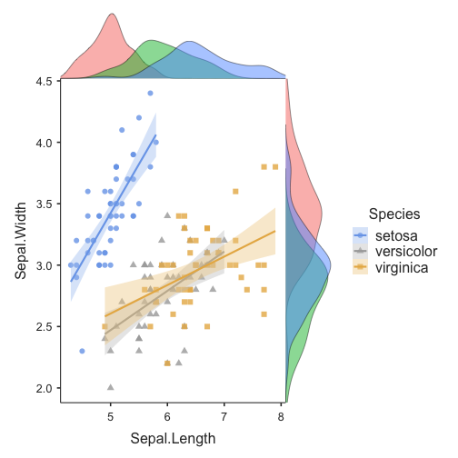

```r
# install.packages('scatr')
scatr::scat(data = irisdata, x = "Sepal.Length", y = "Sepal.Width", group = "Species",
    marg = "dens", line = "linear", se = TRUE)
```

## summarytools

https://cran.r-project.org/web/packages/summarytools/vignettes/Introduction.html

```r
library(summarytools)
summarytools::freq(iris$Species, style = "rmarkdown")
```

### Frequencies

#### iris$Species

**Type:** Factor

|         &nbsp; | Freq | % Valid | % Valid Cum. | % Total | % Total Cum. |
|---------------:|-----:|--------:|-------------:|--------:|-------------:|
|     **setosa** |   50 |   33.33 |        33.33 |   33.33 |        33.33 |
| **versicolor** |   50 |   33.33 |        66.67 |   33.33 |        66.67 |
|  **virginica** |   50 |   33.33 |       100.00 |   33.33 |       100.00 |
|     **\<NA\>** |    0 |         |              |    0.00 |       100.00 |
|      **Total** |  150 |  100.00 |       100.00 |  100.00 |       100.00 |

```r
summarytools::freq(iris$Species, report.nas = FALSE, style = "rmarkdown", headings = FALSE)
```

|         &nbsp; | Freq |      % | % Cum. |
|---------------:|-----:|-------:|-------:|
|     **setosa** |   50 |  33.33 |  33.33 |
| **versicolor** |   50 |  33.33 |  66.67 |
|  **virginica** |   50 |  33.33 | 100.00 |
|      **Total** |  150 | 100.00 | 100.00 |

```r
with(tobacco, print(ctable(smoker, diseased), method = "render"))
```

Cross-Tabulation, Row Proportions

smoker * diseased

**Data Frame**: tobacco

| **smoker** | diseased Yes | diseased Yes | diseased Yes | diseased Yes | diseased No | diseased No | diseased No | diseased No | Total | Total | Total | Total |
| --- | --- | --- | --- | --- | --- | --- | --- | --- | --- | --- | --- | --- |
| **Yes** | 125 | ( | 41.9% | ) | 173 | ( | 58.1% | ) | 298 | ( | 100.0% | ) |
| **No** | 99 | ( | 14.1% | ) | 603 | ( | 85.9% | ) | 702 | ( | 100.0% | ) |
| **Total** | 224 | ( | 22.4% | ) | 776 | ( | 77.6% | ) | 1000 | ( | 100.0% | ) |

Generated by summarytools 0.9.4 ([R](https://www.r-project.org/) version 3.6.0)  
2019-09-25

```r
with(tobacco, print(ctable(smoker, diseased, prop = "n", totals = FALSE), omit.headings = TRUE,
    method = "render"))
```

Cross-Tabulation

smoker * diseased

**Data Frame**: tobacco

| **smoker** | diseased Yes | diseased No |
| --- | --- | --- |
| **Yes** | 125 | 173 |
| **No** | 99 | 603 |

Generated by summarytools 0.9.4 ([R](https://www.r-project.org/) version 3.6.0)  
2019-09-25

```r
summarytools::descr(iris, style = "rmarkdown")
```

### Descriptive Statistics

#### iris

**N:** 150

|          &nbsp; | Petal.Length | Petal.Width | Sepal.Length | Sepal.Width |
|----------------:|-------------:|------------:|-------------:|------------:|
|        **Mean** |         3.76 |        1.20 |         5.84 |        3.06 |
|     **Std.Dev** |         1.77 |        0.76 |         0.83 |        0.44 |
|         **Min** |         1.00 |        0.10 |         4.30 |        2.00 |
|          **Q1** |         1.60 |        0.30 |         5.10 |        2.80 |
|      **Median** |         4.35 |        1.30 |         5.80 |        3.00 |
|          **Q3** |         5.10 |        1.80 |         6.40 |        3.30 |
|         **Max** |         6.90 |        2.50 |         7.90 |        4.40 |
|         **MAD** |         1.85 |        1.04 |         1.04 |        0.44 |
|         **IQR** |         3.50 |        1.50 |         1.30 |        0.50 |
|          **CV** |         0.47 |        0.64 |         0.14 |        0.14 |
|    **Skewness** |        -0.27 |       -0.10 |         0.31 |        0.31 |
| **SE.Skewness** |         0.20 |        0.20 |         0.20 |        0.20 |
|    **Kurtosis** |        -1.42 |       -1.36 |        -0.61 |        0.14 |
|     **N.Valid** |       150.00 |      150.00 |       150.00 |      150.00 |
|   **Pct.Valid** |       100.00 |      100.00 |       100.00 |      100.00 |

```r
descr(iris, stats = c("mean", "sd", "min", "med", "max"), transpose = TRUE,
    headings = FALSE, style = "rmarkdown")
```

|           &nbsp; | Mean | Std.Dev |  Min | Median |  Max |
|-----------------:|-----:|--------:|-----:|-------:|-----:|
| **Petal.Length** | 3.76 |    1.77 | 1.00 |   4.35 | 6.90 |
|  **Petal.Width** | 1.20 |    0.76 | 0.10 |   1.30 | 2.50 |
| **Sepal.Length** | 5.84 |    0.83 | 4.30 |   5.80 | 7.90 |
|  **Sepal.Width** | 3.06 |    0.44 | 2.00 |   3.00 | 4.40 |

```r
# view(dfSummary(iris))
```

[figure not shown]

```r
# First save the results
iris_stats_by_species <- by(data = iris, INDICES = iris$Species, FUN = descr,
    stats = c("mean", "sd", "min", "med", "max"), transpose = TRUE)
# Then use view(), like so:
view(iris_stats_by_species, method = "pander", style = "rmarkdown")
```

### Descriptive Statistics

#### iris

**Group:** Species = setosa
**N:** 50

|           &nbsp; | Mean | Std.Dev |  Min | Median |  Max |
|-----------------:|-----:|--------:|-----:|-------:|-----:|
| **Petal.Length** | 1.46 |    0.17 | 1.00 |   1.50 | 1.90 |
|  **Petal.Width** | 0.25 |    0.11 | 0.10 |   0.20 | 0.60 |
| **Sepal.Length** | 5.01 |    0.35 | 4.30 |   5.00 | 5.80 |
|  **Sepal.Width** | 3.43 |    0.38 | 2.30 |   3.40 | 4.40 |

**Group:** Species = versicolor
**N:** 50

|           &nbsp; | Mean | Std.Dev |  Min | Median |  Max |
|-----------------:|-----:|--------:|-----:|-------:|-----:|
| **Petal.Length** | 4.26 |    0.47 | 3.00 |   4.35 | 5.10 |
|  **Petal.Width** | 1.33 |    0.20 | 1.00 |   1.30 | 1.80 |
| **Sepal.Length** | 5.94 |    0.52 | 4.90 |   5.90 | 7.00 |
|  **Sepal.Width** | 2.77 |    0.31 | 2.00 |   2.80 | 3.40 |

**Group:** Species = virginica
**N:** 50

|           &nbsp; | Mean | Std.Dev |  Min | Median |  Max |
|-----------------:|-----:|--------:|-----:|-------:|-----:|
| **Petal.Length** | 5.55 |    0.55 | 4.50 |   5.55 | 6.90 |
|  **Petal.Width** | 2.03 |    0.27 | 1.40 |   2.00 | 2.50 |
| **Sepal.Length** | 6.59 |    0.64 | 4.90 |   6.50 | 7.90 |
|  **Sepal.Width** | 2.97 |    0.32 | 2.20 |   3.00 | 3.80 |

```r
# view(iris_stats_by_species)
```

[figure not shown]

```r
data(tobacco)  # tobacco is an example dataframe included in the package
BMI_by_age <- with(tobacco, by(BMI, age.gr, descr, stats = c("mean", "sd", "min",
    "med", "max")))
view(BMI_by_age, "pander", style = "rmarkdown")
```

### Descriptive Statistics

#### BMI by age.gr

**Data Frame:** tobacco
**N:** 258

|      &nbsp; | 18-34 | 35-50 | 51-70 |  71 + |
|------------:|------:|------:|------:|------:|
|    **Mean** | 23.84 | 25.11 | 26.91 | 27.45 |
| **Std.Dev** |  4.23 |  4.34 |  4.26 |  4.37 |
|     **Min** |  8.83 | 10.35 |  9.01 | 16.36 |
|  **Median** | 24.04 | 25.11 | 26.77 | 27.52 |
|     **Max** | 34.84 | 39.44 | 39.21 | 38.37 |

```r
BMI_by_age <- with(tobacco, by(BMI, age.gr, descr, transpose = TRUE, stats = c("mean",
    "sd", "min", "med", "max")))

view(BMI_by_age, "pander", style = "rmarkdown", omit.headings = TRUE)
```

### Descriptive Statistics

#### BMI by age.gr

**Data Frame:** tobacco
**N:** 258

|    &nbsp; |  Mean | Std.Dev |   Min | Median |   Max |
|----------:|------:|--------:|------:|-------:|------:|
| **18-34** | 23.84 |    4.23 |  8.83 |  24.04 | 34.84 |
| **35-50** | 25.11 |    4.34 | 10.35 |  25.11 | 39.44 |
| **51-70** | 26.91 |    4.26 |  9.01 |  26.77 | 39.21 |
|  **71 +** | 27.45 |    4.37 | 16.36 |  27.52 | 38.37 |

```r
what.is(iris)
```

$properties
      property      value
1        class data.frame
2       typeof       list
3         mode       list
4 storage.mode       list
5          dim    150 x 5
6       length          5
7    is.object       TRUE
8  object.type         S3
9  object.size 7256 Bytes

$attributes.lengths
    names     class row.names
        5         1       150

$extensive.is
[1] "is.data.frame" "is.list"       "is.object"     "is.recursive"
[5] "is.unsorted"

## DataExplorer

```
library(DataExplorer)
DataExplorer::create_report(df)
```

[figure not shown]

## inspectdf

https://github.com/alastairrushworth/inspectdf

## Grafikler

```
descr(tobacco, style = 'rmarkdown')

print(descr(tobacco), method = 'render', table.classes = 'st-small')

dfSummary(tobacco, style = 'grid', plain.ascii = FALSE)

print(dfSummary(tobacco, graph.magnif = 0.75), method = 'render')
```

> Here, building up a [#ggplot2](https://twitter.com/hashtag/ggplot2?src=hash&ref_src=twsrc%5Etfw) as slowly as possible, [#rstats](https://twitter.com/hashtag/rstats?src=hash&ref_src=twsrc%5Etfw). Incremental adjustments. [#rstatsteachingideas](https://twitter.com/hashtag/rstatsteachingideas?src=hash&ref_src=twsrc%5Etfw) [pic.twitter.com/nUulQl8bPh](https://t.co/nUulQl8bPh)

> — Gina Reynolds (@EvaMaeRey) [August 13, 2018](https://twitter.com/EvaMaeRey/status/1029104656763572226?ref_src=twsrc%5Etfw)

[figure not shown]

> Dreaming of a fancy [#Rstats](https://twitter.com/hashtag/Rstats?src=hash&ref_src=twsrc%5Etfw) [#ggplot](https://twitter.com/hashtag/ggplot?src=hash&ref_src=twsrc%5Etfw) [#dataviz](https://twitter.com/hashtag/dataviz?src=hash&ref_src=twsrc%5Etfw) but still scared of typing [#code](https://twitter.com/hashtag/code?src=hash&ref_src=twsrc%5Etfw)? [@_pvictorr](https://twitter.com/_pvictorr?ref_src=twsrc%5Etfw) esquisse package has you covered https://t.co/1vIDXcVAAF [pic.twitter.com/RlTkptnrNv](https://t.co/RlTkptnrNv)

> — Radoslaw Panczak (@RPanczak) [October 2, 2018](https://twitter.com/RPanczak/status/1047019588658040832?ref_src=twsrc%5Etfw)

# Bazı arayüzler

https://sbalci.github.io/MyRCodesForDataAnalysis/R-Arayuzler.nb.html

## Rcmdr

```
library(Rcmdr)

Rcmdr::Commander()
```

- A Comparative Review of the R Commander GUI for R

http://r4stats.com/articles/software-reviews/r-commander/

## jamovi

https://www.jamovi.org/

[figure not shown]

https://blog.jamovi.org/2018/07/30/rj.html

[figure not shown]

# R nereden öğrenilir

https://sbalci.github.io/MyRCodesForDataAnalysis/WhereToLearnR.nb.html

# Sonraki Konular

- RStudio ile GitHub kullanımı
- R Markdown ve R Notebook ile tekrarlanabilir rapor
- Hipotez testleri

-----

# Geri Bildirim

- Geri bildirim için tıklayınız: _[Geri bildirim formu](https://goo.gl/forms/YjGZ5DHgtPlR1RnB3)_

# Libraries Used

```
citation("tidyverse")
citation("foreign")
citation("tidylog")
citation("janitor")
citation("jmv")
citation("tangram")
citation("finalfit")
citation("summarytools")
citation("ggstatplot")
citation("readxl")
```

# İletişim

Completed on 2019-09-25 19:08:42.

Serdar Balci, MD, Pathologist
drserdarbalci@gmail.com

https://rpubs.com/sbalci/CV
https://sbalci.github.io/
https://github.com/sbalci
https://twitter.com/serdarbalci